# Craft Beers

Linda Eliasen/Limin Zheng

February 23, 2019

## bringing in data files

Top and Bottom of Brewery Data Set

| Brewery | Beer | Style | ABV | IBU | Ounces | City | State | Beer_ID | Brewery_id |
| --- | --- | --- | --- | --- | --- | --- | --- | --- | --- |
| NorthGate Brewing | Pumpion | Pumpkin Ale | 0.060 | 38 | 16 | Minneapolis | MN | 2689 | 1 |
| NorthGate Brewing | Stronghold | American Porter | 0.060 | 25 | 16 | Minneapolis | MN | 2688 | 1 |
| NorthGate Brewing | Parapet ESB | Extra Special / Strong Bitter (ESB) | 0.056 | 47 | 16 | Minneapolis | MN | 2687 | 1 |
| NorthGate Brewing | Get Together | American IPA | 0.045 | 50 | 16 | Minneapolis | MN | 2692 | 1 |
| NorthGate Brewing | Maggie’s Leap | Milk / Sweet Stout | 0.049 | 26 | 16 | Minneapolis | MN | 2691 | 1 |
| NorthGate Brewing | Wall’s End | English Brown Ale | 0.048 | 19 | 16 | Minneapolis | MN | 2690 | 1 |

|  | Brewery | Beer | Style | ABV | IBU | Ounces | City | State | Beer_ID | Brewery_id |
| --- | --- | --- | --- | --- | --- | --- | --- | --- | --- | --- |
| 2405 | Ukiah Brewing Company | Pilsner Ukiah | German Pilsener | 0.055 | NA | 12 | Ukiah | CA | 98 | 556 |
| 2406 | Butternuts Beer and Ale | Porkslap Pale Ale | American Pale Ale (APA) | 0.043 | NA | 12 | Garrattsville | NY | 49 | 557 |
| 2407 | Butternuts Beer and Ale | Snapperhead IPA | American IPA | 0.068 | NA | 12 | Garrattsville | NY | 51 | 557 |
| 2408 | Butternuts Beer and Ale | Moo Thunder Stout | Milk / Sweet Stout | 0.049 | NA | 12 | Garrattsville | NY | 50 | 557 |
| 2409 | Butternuts Beer and Ale | Heinnieweisse Weissebier | Hefeweizen | 0.049 | NA | 12 | Garrattsville | NY | 52 | 557 |
| 2410 | Sleeping Lady Brewing Company | Urban Wilderness Pale Ale | English Pale Ale | 0.049 | NA | 12 | Anchorage | AK | 30 | 558 |

Report the number of NA’s in each column.

|  | x |
| --- | --- |
| Brewery | 0 |
| Beer | 0 |
| Style | 0 |
| ABV | 62 |
| IBU | 1005 |
| Ounces | 0 |
| City | 0 |
| State | 0 |
| Beer_ID | 0 |
| Brewery_id | 0 |

How many breweries are present in each state? Compute the median alcohol content and international bitterness unit for each state, plus adding in other data elements from third file

| State | MedianABV | MedianIBU | Breweries | BreweriesPerCapita | EconomicImpactM$ | EconomicImpactRank | BarrelsPerYear | GallonsPerAdult |
| --- | --- | --- | --- | --- | --- | --- | --- | --- |
| AK | 0.0560 | 46.0 | 7 | 6.8 | 232 | 45 | 204302 | 12.0 |
| AL | 0.0600 | 43.0 | 3 | 0.9 | 616 | 29 | 62738 | 0.5 |
| AR | 0.0520 | 39.0 | 2 | 1.6 | 406 | 37 | 42294 | 0.6 |
| AZ | 0.0550 | 20.5 | 11 | 1.9 | 1000 | 22 | 147728 | 0.9 |
| CA | 0.0580 | 42.0 | 39 | 2.6 | 7345 | 1 | 3285525 | 3.5 |
| CO | 0.0605 | 40.0 | 47 | 8.4 | 3037 | 6 | 1523204 | 11.4 |
| CT | 0.0600 | 29.0 | 8 | 2.2 | 718 | 26 | 166848 | 1.9 |
| DC | 0.0625 | 47.5 | 1 | 2.2 | 235 | 47 | 33025 | 1.9 |
| DE | 0.0550 | 52.0 | 2 | 2.9 | 318 | 41 | 292741 | 12.6 |
| FL | 0.0570 | 55.0 | 15 | 1.5 | 3074 | 5 | 1408032 | 2.7 |
| GA | 0.0550 | 55.0 | 7 | 0.9 | 1596 | 17 | 408798 | 1.7 |
| HI | 0.0540 | 22.5 | 4 | 1.7 | 245 | 46 | 69561 | 2.0 |
| IA | 0.0555 | 26.0 | 5 | 3.3 | 861 | 23 | 78946 | 1.1 |
| ID | 0.0565 | 39.0 | 5 | 4.5 | 366 | 38 | 90318 | 2.3 |
| IL | 0.0580 | 30.0 | 18 | 2.1 | 2602 | 8 | 385874 | 1.3 |
| IN | 0.0580 | 33.0 | 22 | 2.8 | 1309 | 19 | 240063 | 1.5 |
| KS | 0.0500 | 20.0 | 3 | 1.7 | 480 | 31 | 46725 | 0.7 |
| KY | 0.0625 | 31.5 | 4 | 1.6 | 657 | 27 | 125302 | 1.2 |
| LA | 0.0520 | 31.5 | 5 | 1.0 | 740 | 25 | 215168 | 2.0 |
| MA | 0.0540 | 35.0 | 23 | 2.5 | 1838 | 14 | 584895 | 3.5 |
| MD | 0.0580 | 29.0 | 7 | 1.6 | 826 | 24 | 293298 | 2.0 |
| ME | 0.0510 | 61.0 | 9 | 9.6 | 476 | 32 | 319590 | 9.6 |
| MI | 0.0620 | 35.0 | 32 | 4.5 | 2094 | 9 | 873995 | 3.7 |
| MN | 0.0560 | 44.5 | 12 | 3.9 | 2007 | 12 | 650974 | 5.0 |
| MO | 0.0520 | 24.0 | 9 | 2.0 | 1047 | 21 | 372840 | 2.6 |
| MS | 0.0580 | 45.0 | 2 | 0.6 | 310 | 42 | 30254 | 0.4 |
| MT | 0.0550 | 40.0 | 9 | 9.6 | 417 | 35 | 188449 | 7.5 |
| NC | 0.0570 | 33.5 | 19 | 3.4 | 2042 | 10 | 1211393 | 5.0 |
| ND | 0.0500 | 32.0 | 1 | 2.2 | 200 | 49 | 12848 | 0.7 |
| NE | 0.0560 | 35.0 | 5 | 3.6 | 465 | 33 | 53655 | 1.2 |
| NH | 0.0550 | 48.5 | 3 | 5.6 | 353 | 39 | 103329 | 3.1 |
| NJ | 0.0460 | 34.5 | 3 | 1.3 | 1636 | 16 | 139562 | 0.6 |
| NM | 0.0620 | 51.0 | 4 | 4.4 | 333 | 40 | 116023 | 2.4 |
| NV | 0.0600 | 41.0 | 2 | 1.8 | 434 | 34 | 64621 | 0.9 |
| NY | 0.0550 | 47.0 | 16 | 2.2 | 3439 | 4 | 1211494 | 2.5 |
| OH | 0.0580 | 40.0 | 15 | 2.6 | 2675 | 7 | 1355279 | 4.9 |
| OK | 0.0600 | 35.0 | 6 | 1.0 | 502 | 30 | 52807 | 0.6 |
| OR | 0.0560 | 40.0 | 29 | 8.5 | 1988 | 13 | 1078391 | 10.7 |
| PA | 0.0570 | 30.0 | 25 | 2.9 | 5788 | 2 | 3724010 | 12.0 |
| RI | 0.0550 | 24.0 | 5 | 2.1 | 152 | 51 | 26295 | 1.0 |
| SC | 0.0550 | 30.0 | 4 | 1.6 | 650 | 28 | 108211 | 0.9 |
| SD | 0.0600 | NA | 1 | 2.6 | 209 | 48 | 14057 | 0.7 |
| TN | 0.0570 | 37.0 | 3 | 1.7 | 1135 | 20 | 253782 | 1.6 |
| TX | 0.0550 | 33.0 | 28 | 1.3 | 4540 | 3 | 1156536 | 1.8 |
| UT | 0.0400 | 34.0 | 4 | 1.5 | 415 | 36 | 206529 | 3.1 |
| VA | 0.0565 | 42.0 | 16 | 3.0 | 1373 | 18 | 358903 | 1.8 |
| VT | 0.0550 | 30.0 | 10 | 11.5 | 309 | 43 | 292479 | 18.9 |
| WA | 0.0555 | 38.0 | 23 | 6.7 | 1770 | 15 | 510682 | 2.9 |
| WI | 0.0520 | 19.0 | 20 | 3.7 | 2015 | 11 | 1029916 | 7.5 |
| WV | 0.0620 | 57.5 | 1 | 1.7 | 293 | 44 | 12989 | 0.3 |
| WY | 0.0500 | 21.0 | 4 | 5.7 | 177 | 50 | 45401 | 3.3 |

Heat map number of breweries by state

[interactive chart not shown]

Plot a bar chart to compare.

Median Alcohol content

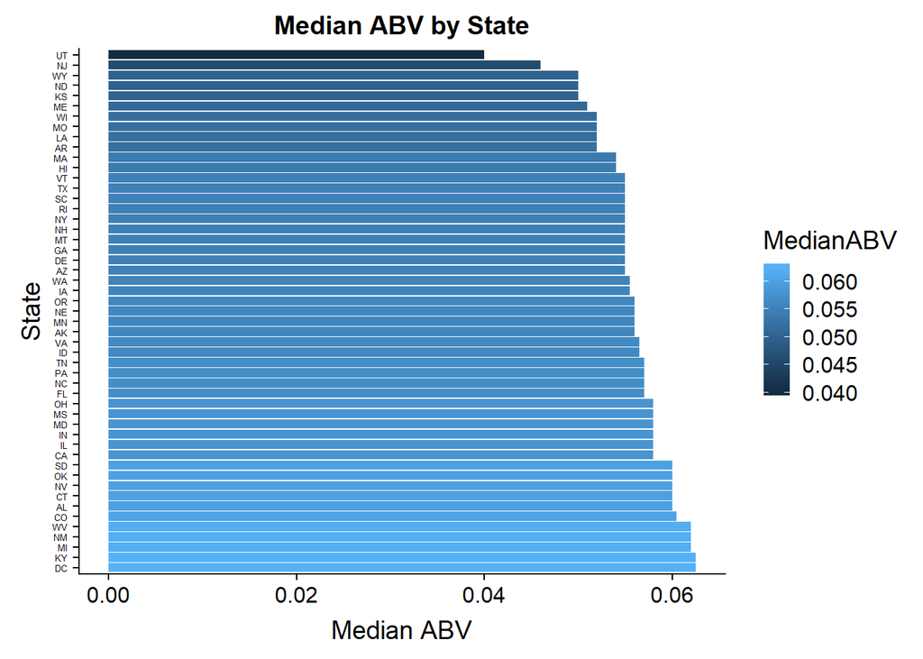

Median International Bitterness Level by State

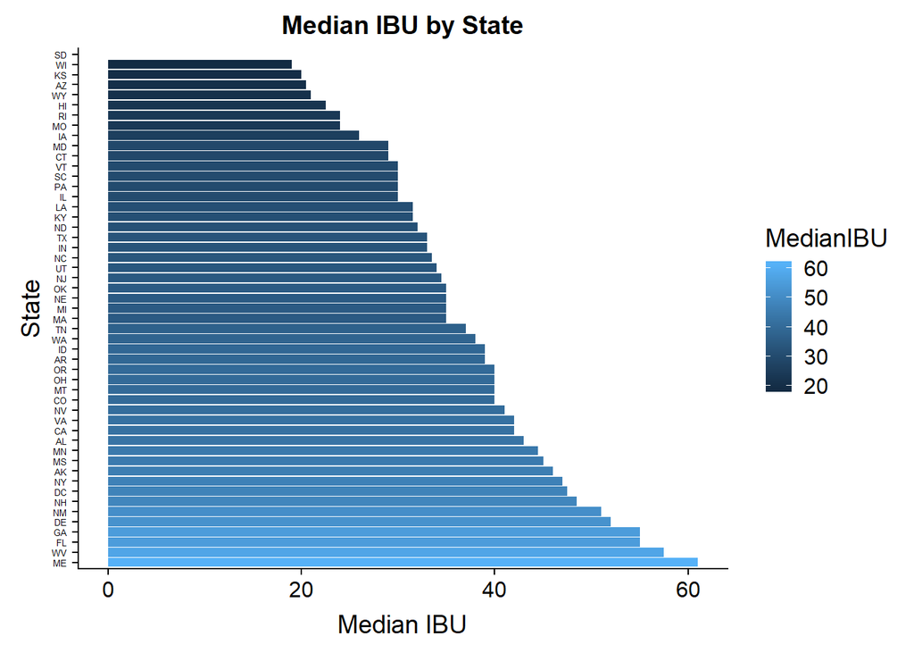

charts side by side… needs widening

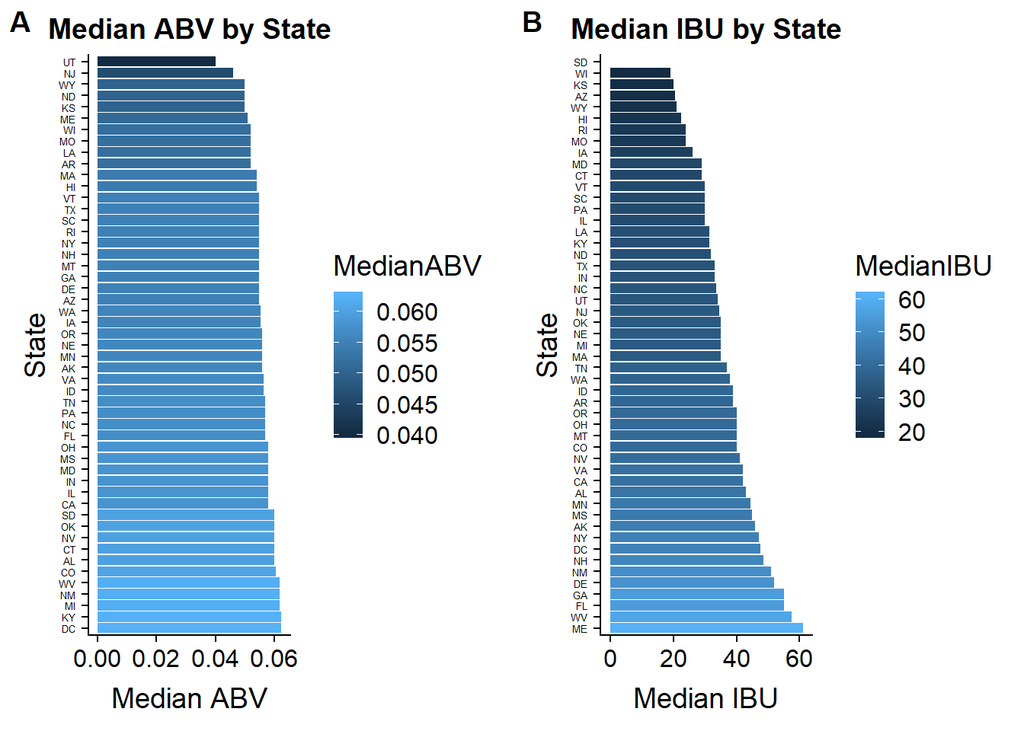

Which state has the maximum alcoholic (ABV) beer? Which state has the most bitter (IBU) beer?

State with Highest ABV and Most Bitter Beer

[output not shown]

Summary statistics for the ABV variable (also adding in IBU)

|  | Min. | 1st Qu. | Median | Mean | 3rd Qu. | Max. | NA’s |
| --- | --- | --- | --- | --- | --- | --- | --- |
| AlcoholbyVolume | 0.001 | 0.05 | 0.056 | 0.05980 | 0.067 | 0.128 | 62 |
| InternationalBitterness | 4.000 | 21.00 | 35.000 | 42.71317 | 64.000 | 138.000 | 1005 |

|  | Min. | 1st Qu. | Median | Mean | 3rd Qu. | Max. |
| --- | --- | --- | --- | --- | --- | --- |
| EconomicImpactInMillions | 152 | 359.5 | 718 | 1328.333 | 1913.0 | 7345 |
| AnnualProductionBarrels | 12848 | 67091.0 | 206529 | 495699.588 | 547788.5 | 3724010 |

Is there an apparent relationship between the bitterness of the beer and its alcoholic content?

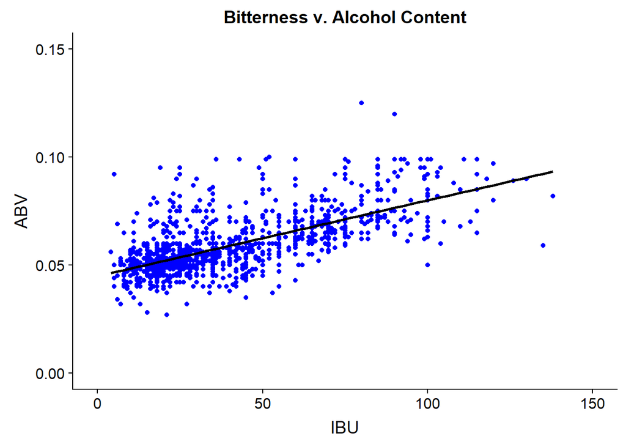

ADDITIONAL CHARTS

Number of different craft beers in each state

|  | State | BeerTypes |
| --- | --- | --- |
| 6 | CO | 252 |
| 5 | CA | 173 |
| 23 | MI | 160 |
| 16 | IN | 138 |
| 44 | TX | 127 |
| 38 | OR | 114 |
| 39 | PA | 100 |
| 15 | IL | 87 |
| 20 | MA | 79 |
| 49 | WI | 78 |
| 35 | NY | 72 |
| 48 | WA | 67 |
| 10 | FL | 57 |
| 28 | NC | 56 |
| 24 | MN | 55 |
| 36 | OH | 48 |
| 4 | AZ | 46 |
| 25 | MO | 42 |
| 27 | MT | 39 |
| 46 | VA | 38 |
| 13 | IA | 30 |
| 14 | ID | 28 |
| 7 | CT | 27 |
| 22 | ME | 27 |
| 40 | RI | 26 |
| 1 | AK | 25 |
| 45 | UT | 25 |
| 47 | VT | 25 |
| 30 | NE | 23 |
| 12 | HI | 22 |
| 17 | KS | 22 |
| 21 | MD | 20 |
| 18 | KY | 19 |
| 19 | LA | 19 |
| 37 | OK | 19 |
| 11 | GA | 16 |
| 51 | WY | 15 |
| 33 | NM | 14 |
| 41 | SC | 14 |
| 34 | NV | 11 |
| 2 | AL | 10 |
| 26 | MS | 9 |
| 8 | DC | 8 |
| 31 | NH | 8 |
| 32 | NJ | 8 |
| 42 | SD | 7 |
| 43 | TN | 6 |
| 3 | AR | 5 |
| 29 | ND | 3 |
| 9 | DE | 2 |
| 50 | WV | 2 |

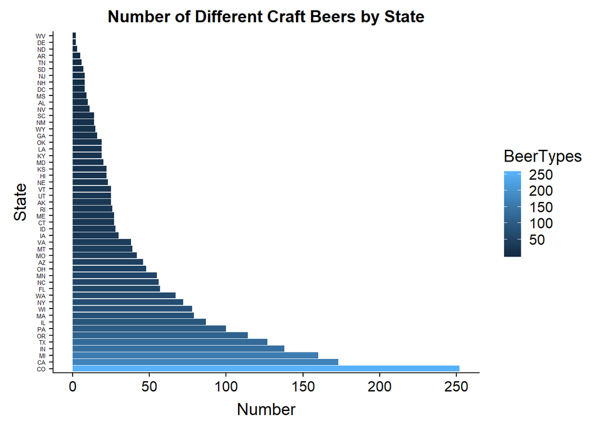

Number of different beer STYLES in each state

|  | State | BeerStyles |
| --- | --- | --- |
| 6 | CO | 61 |
| 16 | IN | 47 |
| 5 | CA | 46 |
| 23 | MI | 46 |
| 44 | TX | 46 |
| 39 | PA | 42 |
| 35 | NY | 35 |
| 15 | IL | 34 |
| 20 | MA | 33 |
| 49 | WI | 30 |
| 38 | OR | 29 |
| 24 | MN | 25 |
| 28 | NC | 25 |
| 36 | OH | 24 |
| 48 | WA | 23 |
| 25 | MO | 21 |
| 46 | VA | 21 |
| 4 | AZ | 19 |
| 10 | FL | 19 |
| 14 | ID | 19 |
| 27 | MT | 18 |
| 13 | IA | 17 |
| 18 | KY | 17 |
| 22 | ME | 17 |
| 30 | NE | 17 |
| 40 | RI | 17 |
| 45 | UT | 17 |
| 21 | MD | 16 |
| 47 | VT | 16 |
| 7 | CT | 15 |
| 12 | HI | 15 |
| 17 | KS | 15 |
| 1 | AK | 14 |
| 19 | LA | 12 |
| 37 | OK | 12 |
| 41 | SC | 11 |
| 33 | NM | 10 |
| 34 | NV | 10 |
| 51 | WY | 10 |
| 11 | GA | 9 |
| 2 | AL | 8 |
| 8 | DC | 8 |
| 26 | MS | 8 |
| 42 | SD | 7 |
| 32 | NJ | 6 |
| 3 | AR | 5 |
| 31 | NH | 5 |
| 43 | TN | 5 |
| 29 | ND | 3 |
| 9 | DE | 2 |
| 50 | WV | 2 |

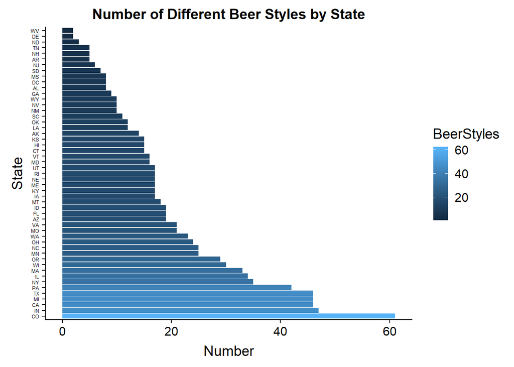

Beer and Brand Style by State

|  | State | BeerTypes | BeerStyles |
| --- | --- | --- | --- |
| 6 | CO | 252 | 61 |
| 16 | IN | 138 | 47 |
| 5 | CA | 173 | 46 |
| 23 | MI | 160 | 46 |
| 44 | TX | 127 | 46 |
| 39 | PA | 100 | 42 |
| 35 | NY | 72 | 35 |
| 15 | IL | 87 | 34 |
| 20 | MA | 79 | 33 |
| 49 | WI | 78 | 30 |
| 38 | OR | 114 | 29 |
| 24 | MN | 55 | 25 |
| 28 | NC | 56 | 25 |
| 36 | OH | 48 | 24 |
| 48 | WA | 67 | 23 |
| 25 | MO | 42 | 21 |
| 46 | VA | 38 | 21 |
| 4 | AZ | 46 | 19 |
| 10 | FL | 57 | 19 |
| 14 | ID | 28 | 19 |
| 27 | MT | 39 | 18 |
| 13 | IA | 30 | 17 |
| 18 | KY | 19 | 17 |
| 22 | ME | 27 | 17 |
| 30 | NE | 23 | 17 |
| 40 | RI | 26 | 17 |
| 45 | UT | 25 | 17 |
| 21 | MD | 20 | 16 |
| 47 | VT | 25 | 16 |
| 7 | CT | 27 | 15 |
| 12 | HI | 22 | 15 |
| 17 | KS | 22 | 15 |
| 1 | AK | 25 | 14 |
| 19 | LA | 19 | 12 |
| 37 | OK | 19 | 12 |
| 41 | SC | 14 | 11 |
| 33 | NM | 14 | 10 |
| 34 | NV | 11 | 10 |
| 51 | WY | 15 | 10 |
| 11 | GA | 16 | 9 |
| 2 | AL | 10 | 8 |
| 8 | DC | 8 | 8 |
| 26 | MS | 9 | 8 |
| 42 | SD | 7 | 7 |
| 32 | NJ | 8 | 6 |
| 3 | AR | 5 | 5 |
| 31 | NH | 8 | 5 |
| 43 | TN | 6 | 5 |
| 29 | ND | 3 | 3 |
| 9 | DE | 2 | 2 |
| 50 | WV | 2 | 2 |

Treemap of Beer Styles

[interactive chart not shown]

|  | State | EconomicImpactRank |
| --- | --- | --- |
| 40 | RI | 51 |
| 51 | WY | 50 |
| 29 | ND | 49 |
| 42 | SD | 48 |
| 8 | DC | 47 |
| 12 | HI | 46 |
| 1 | AK | 45 |
| 50 | WV | 44 |
| 47 | VT | 43 |
| 26 | MS | 42 |

Revenue by State in M$

|  | State | EconomicImpactMil |
| --- | --- | --- |
| 5 | CA | 7345 |
| 39 | PA | 5788 |
| 44 | TX | 4540 |
| 35 | NY | 3439 |
| 10 | FL | 3074 |
| 6 | CO | 3037 |
| 36 | OH | 2675 |
| 15 | IL | 2602 |
| 23 | MI | 2094 |
| 28 | NC | 2042 |

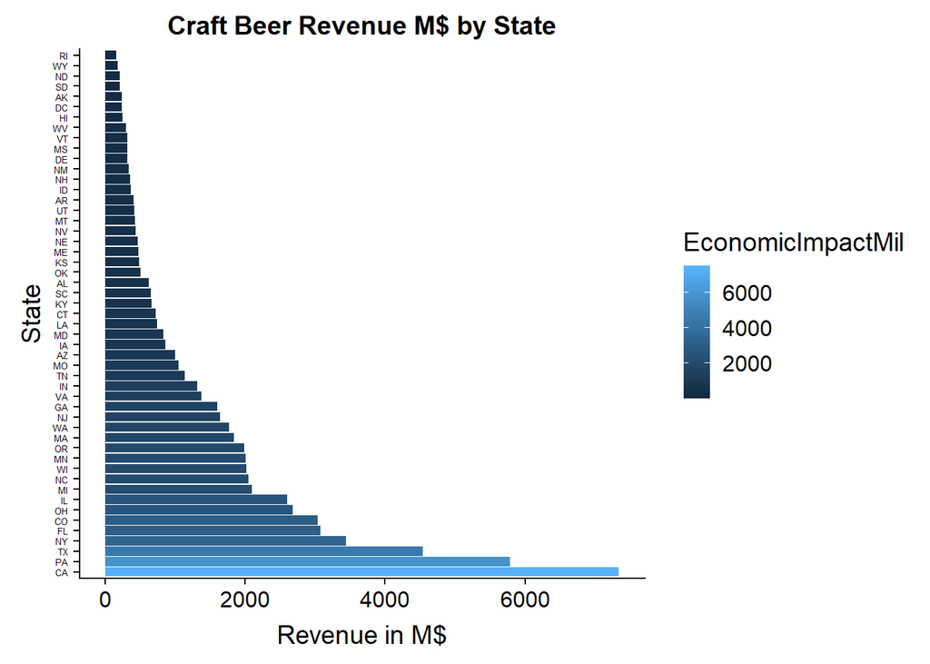

Gallons Per Adult 21+ by State

|  | State | GallonsPerAdult |
| --- | --- | --- |
| 47 | VT | 18.9 |
| 9 | DE | 12.6 |
| 1 | AK | 12.0 |
| 39 | PA | 12.0 |
| 6 | CO | 11.4 |
| 38 | OR | 10.7 |
| 22 | ME | 9.6 |
| 27 | MT | 7.5 |
| 49 | WI | 7.5 |
| 24 | MN | 5.0 |

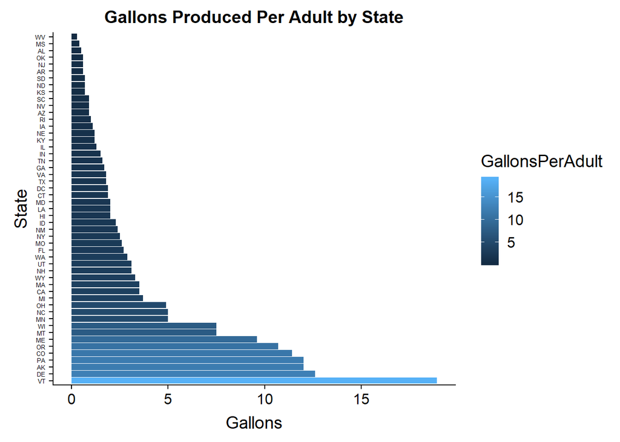

write.csv(statesum,‘statesum.csv’)

##### Sources

*https://www.datacamp.com/community/tutorials/data-visualization-highcharter-r*